# Starbucks Capstone Challenge

# Table of Content

- Project Overview
  - Introduction
  - Problem Statement
  - Procedure
  - Data set
- Data wrangling
  - Gathering data
  - Assesing data
  - Cleaning data
  - Merge data frames
  - Save cleaned data
- Exploratory data analysis
  - Prepare data for analysis
  - Data visualization
- Machine Learning approche for recommendations
  - Prepare data for a machine learning approche
  - Test different machine learning models (Gaussian Naive Bayes, Adaboost and the RandomForestClassifier)
  - Tuning of the machine learning model
  - Get most predictive features
- Results
  - Improvements
  - Reflection

# 1. Project Overview

## 1.1. Introduction

This project is a a capstone of the Udacity Nanodegree: Data Science. It uses simulated data that mimics customer behavior on the Starbucks rewards mobile app. An offer can be merely an advertisement for a drink or an actual offer such as a discount or a 'buy one get one free' (BOGO). Not all users received the asme offers or some users might even not receive any offer during certain weeks. Besides this it could also happen that an user will complete an offer without seeing it by just buying regularly his or her coffee. Therefore one should also take care if a user has viewed the offer before completing it.

#### Example

To give an example, a user could receive a discount offer buy 10 dollars get 2 off on Monday. The offer is valid for 10 days from receipt. If the customer accumulates at least 10 dollars in purchases during the validity period, the customer completes the offer.

However, there are a few things to watch out for in this data set. Customers do not opt into the offers that they receive; in other words, a user can receive an offer, never actually view the offer, and still complete the offer. For example, a user might receive the "buy 10 dollars get 2 dollars off offer", but the user never opens the offer during the 10 day validity period. The customer spends 15 dollars during those ten days. There will be an offer completion record in the data set; however, the customer was not influenced by the offer because the customer never viewed the offer.

#### Cleaning

This makes data cleaning especially important and tricky.

You'll also want to take into account that some demographic groups will make purchases even if they don't receive an offer. From a business perspective, if a customer is going to make a 10 dollar purchase without an offer anyway, you wouldn't want to send a buy 10 dollars get 2 dollars off offer. You'll want to try to assess what a certain demographic group will buy when not receiving any offers.

#### Final Advice

Because this is a capstone project, you are free to analyze the data any way you see fit. For example, you could build a machine learning model that predicts how much someone will spend based on demographics and offer type. Or you could build a model that predicts whether or not someone will respond to an offer. Or, you don't need to build a machine learning model at all. You could develop a set of heuristics that determine what offer you should send to each customer (i.e., 75 percent of women customers who were 35 years old responded to offer A vs 40 percent from the same demographic to offer B, so send offer A).

## 1.2. Problem Statement

In this project I try mo improve the advertisement strategy for Starbucks.  
To be succesful on this task I will mainly focus on the following five quesitons:

- What are the most predictive features or parameters for a completed offer
- What are the relations between the customer age, income and offer completion rate?
- Is the customer gender important for the offer completion rate?
- What is the most important channel for completing an offer?
- Is there any correlation between the offer types and offer completion rate?

## 1.3. Procedure

I will proceed the following steps to answer the above mentioned questions and successfully complete this project:

- Data wrangling  
  The Data wrangling chapter consists of multiple steps, namely: 'gathering data', 'assesing data' and 'cleaning data'. This is about loading and analyzing the input data sets, as well as cleaning the data that they can be used for further investigations. At the end I will merge the data frames to have one complete cleaned data frame which will be saved. In this way all the cleaning steps do not need to be repeated if one wants to analyze the data later on.
- Exploratory data analysis  
  The exploratory data analysis is about the analysis and visualization of the data. First of all, on gets a deeper feeling of the data, prepares first insights and if possible also answers the first questions from the problem set.
- Machine Learning approche for recommendations  
  After the data analysis, a chapter will present a machine learning approche for recommentations. First of all three different machine learning models will be used with training and test data, best best predicting model will be improved and used to predict the most predictive features on which Starbucks can then focus.
- Recommendations  
  The last section will summarize the results and give some recommendations for Starbucks advertisement campaign.

## 1.4. Data Sets

The data is contained in three files:

- portfolio.json - containing offer ids and meta data about each offer (duration, type, etc.)
- profile.json - demographic data for each customer
- transcript.json - records for transactions, offers received, offers viewed, and offers completed

Here is the schema and explanation of each variable in the files:

**portfolio.json**

- id (string) - offer id
- offer_type (string) - type of offer ie BOGO [Buy one, get one free], discount, informational
- difficulty (int) - minimum required spend to complete an offer
- reward (int) - reward given for completing an offer
- duration (int) - time for offer to be open, in days
- channels (list of strings)

**profile.json**

- age (int) - age of the customer
- became_member_on (int) - date when customer created an app account
- gender (str) - gender of the customer (note some entries contain 'O' for other rather than M or F)
- id (str) - customer id
- income (float) - customer's income

**transcript.json**

- event (str) - record description (ie transaction, offer received, offer viewed, etc.)
- person (str) - customer id
- time (int) - time in hours since start of test. The data begins at time t=0
- value - (dict of strings) - either an offer id or transaction amount depending on the record

# 2. Data wrangling

This section consists of the three steps:

1. Gathering data
   - within the first step, the relevant data will be loaded
2. Assesing data
   - in this steps the data frames will be analysed and issues will be collected
3. Cleaning data
   - in the last steps, the findings will be cleaned a suitable data framework will be created

### Import packages

```python
import pandas as pd
import numpy as np
import math
import json
from time import time
import seaborn as sns
import matplotlib.pyplot as plt
import matplotlib.patches as mpatches
% matplotlib inline

# sklearn packages used for ml recommendation
from sklearn.metrics import fbeta_score, accuracy_score, classification_report, make_scorer
from sklearn.model_selection import GridSearchCV, train_test_split
# ml models
from sklearn.ensemble import AdaBoostClassifier
from sklearn.ensemble import RandomForestClassifier
from sklearn.naive_bayes import GaussianNB
#from sklearn import svm # not used, because to slow
```

## 2.1. Gathering data

### Load data

```python
# read in the json files
portfolio = pd.read_json('data/portfolio.json', orient='records', lines=True)
profile = pd.read_json('data/profile.json', orient='records', lines=True)
transcript = pd.read_json('data/transcript.json', orient='records', lines=True)
```

## 2.2. Assesing data

### Get an overview of the data

```python
portfolio.head()
```

|  | channels | difficulty | duration | id | offer_type | reward |
| --- | --- | --- | --- | --- | --- | --- |
| 0 | [email, mobile, social] | 10 | 7 | ae264e3637204a6fb9bb56bc8210ddfd | bogo | 10 |
| 1 | [web, email, mobile, social] | 10 | 5 | 4d5c57ea9a6940dd891ad53e9dbe8da0 | bogo | 10 |
| 2 | [web, email, mobile] | 0 | 4 | 3f207df678b143eea3cee63160fa8bed | informational | 0 |
| 3 | [web, email, mobile] | 5 | 7 | 9b98b8c7a33c4b65b9aebfe6a799e6d9 | bogo | 5 |
| 4 | [web, email] | 20 | 10 | 0b1e1539f2cc45b7b9fa7c272da2e1d7 | discount | 5 |

```python
portfolio.channels
```

```
0         [email, mobile, social]
1    [web, email, mobile, social]
2            [web, email, mobile]
3            [web, email, mobile]
4                    [web, email]
5    [web, email, mobile, social]
6    [web, email, mobile, social]
7         [email, mobile, social]
8    [web, email, mobile, social]
9            [web, email, mobile]
Name: channels, dtype: object
```

*remark on column 'channels'*: channels shall be separated in individual columns and 1 shall indicate that channel has been used and 0 that is has not been used. Dummy variables to create: 'email', 'mobile', 'social', 'web'

```python
portfolio.offer_type
```

```
0             bogo
1             bogo
2    informational
3             bogo
4         discount
5         discount
6         discount
7    informational
8             bogo
9         discount
Name: offer_type, dtype: object
```

*remark on column 'offer type'*: 'offer type' shall be separated in individual columns and 1 shall indicate that offer_type has been used and 0 that is has not been used. Dummy variables to create: 'bogo', 'informational', 'discount'

```python
portfolio.info()
```

```
<class 'pandas.core.frame.DataFrame'>
RangeIndex: 10 entries, 0 to 9
Data columns (total 6 columns):
channels      10 non-null object
difficulty    10 non-null int64
duration      10 non-null int64
id            10 non-null object
offer_type    10 non-null object
reward        10 non-null int64
dtypes: int64(3), object(3)
memory usage: 560.0+ bytes
```

all columns seem to be complete

```python
portfolio.describe()
```

|  | difficulty | duration | reward |
| --- | --- | --- | --- |
| count | 10.000000 | 10.000000 | 10.000000 |
| mean | 7.700000 | 6.500000 | 4.200000 |
| std | 5.831905 | 2.321398 | 3.583915 |
| min | 0.000000 | 3.000000 | 0.000000 |
| 25% | 5.000000 | 5.000000 | 2.000000 |
| 50% | 8.500000 | 7.000000 | 4.000000 |
| 75% | 10.000000 | 7.000000 | 5.000000 |
| max | 20.000000 | 10.000000 | 10.000000 |

```python
profile.head()
```

|  | age | became_member_on | gender | id | income |
| --- | --- | --- | --- | --- | --- |
| 0 | 118 | 20170212 | None | 68be06ca386d4c31939f3a4f0e3dd783 | NaN |
| 1 | 55 | 20170715 | F | 0610b486422d4921ae7d2bf64640c50b | 112000.0 |
| 2 | 118 | 20180712 | None | 38fe809add3b4fcf9315a9694bb96ff5 | NaN |
| 3 | 75 | 20170509 | F | 78afa995795e4d85b5d9ceeca43f5fef | 100000.0 |
| 4 | 118 | 20170804 | None | a03223e636434f42ac4c3df47e8bac43 | NaN |

```python
profile.info()
```

```
<class 'pandas.core.frame.DataFrame'>
RangeIndex: 17000 entries, 0 to 16999
Data columns (total 5 columns):
age                 17000 non-null int64
became_member_on    17000 non-null int64
gender              14825 non-null object
id                  17000 non-null object
income              14825 non-null float64
dtypes: float64(1), int64(2), object(2)
memory usage: 664.1+ KB
```

```python
nof_missing_values = profile['gender'].notnull().sum()
print('{} values aremissing. This corresponds to {} %.'.format(profile.shape[0]-nof_missing_values, 100* (1-nof_missing_values/profile.shape[0])))
print()
```

```
2175 values aremissing. This corresponds to 12.794117647058822 %.
```

*remark on data frame profile*: It looks like 2175 values are missing on the columns 'gender' and 'income'.

```python
profile.describe()
```

|  | age | became_member_on | income |
| --- | --- | --- | --- |
| count | 17000.000000 | 1.700000e+04 | 14825.000000 |
| mean | 62.531412 | 2.016703e+07 | 65404.991568 |
| std | 26.738580 | 1.167750e+04 | 21598.299410 |
| min | 18.000000 | 2.013073e+07 | 30000.000000 |
| 25% | 45.000000 | 2.016053e+07 | 49000.000000 |
| 50% | 58.000000 | 2.017080e+07 | 64000.000000 |
| 75% | 73.000000 | 2.017123e+07 | 80000.000000 |
| max | 118.000000 | 2.018073e+07 | 120000.000000 |

```
Text(0,0.5,'Counts')
```

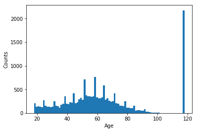

```python
# plot histogram of age
plt.hist(profile.age, bins=len(profile.age.unique()));
plt.xlabel('Age')
plt.ylabel('Counts')
```

*remark on the column age*: Quite a lot of 118 years old customers in the list -> will be further investigated

```python
profile[profile.age>110].sample(5)
```

|  | age | became_member_on | gender | id | income |
| --- | --- | --- | --- | --- | --- |
| 6680 | 118 | 20170730 | None | 62dd66d3bb1c4153b6126caa0a9f8235 | NaN |
| 9882 | 118 | 20170204 | None | 95e1989381514c7bb26c6bd8c469beed | NaN |
| 13541 | 118 | 20130802 | None | e431ebcc6f944c5c9a2d93cbd4a790d7 | NaN |
| 12870 | 118 | 20180723 | None | d32aa738e03f44feac7ec3db9ec12baa | NaN |
| 8190 | 118 | 20151216 | None | 1184d2054c9c44c9adea0068d8bdd508 | NaN |

```python
profile[profile.age>110].gender.unique()
```

```
array([None], dtype=object)
```

```python
profile[profile.age>110].income.unique()
```

```
array([ nan])
```

*remark 2 on the age*: It looks like that the age 118 is a placeholer for not complete profiles, because also the gender and income is unknown. It is just ~13%, therefore we will delete this entries for the first try.

```python
transcript.head()
```

|  | event | person | time | value |
| --- | --- | --- | --- | --- |
| 0 | offer received | 78afa995795e4d85b5d9ceeca43f5fef | 0 | {'offer id': '9b98b8c7a33c4b65b9aebfe6a799e6d9'} |
| 1 | offer received | a03223e636434f42ac4c3df47e8bac43 | 0 | {'offer id': '0b1e1539f2cc45b7b9fa7c272da2e1d7'} |
| 2 | offer received | e2127556f4f64592b11af22de27a7932 | 0 | {'offer id': '2906b810c7d4411798c6938adc9daaa5'} |
| 3 | offer received | 8ec6ce2a7e7949b1bf142def7d0e0586 | 0 | {'offer id': 'fafdcd668e3743c1bb461111dcafc2a4'} |
| 4 | offer received | 68617ca6246f4fbc85e91a2a49552598 | 0 | {'offer id': '4d5c57ea9a6940dd891ad53e9dbe8da0'} |

```python
# test entries for a person
transcript[transcript.person == transcript.person[1]]
```

|  | event | person | time | value |
| --- | --- | --- | --- | --- |
| 1 | offer received | a03223e636434f42ac4c3df47e8bac43 | 0 | {'offer id': '0b1e1539f2cc45b7b9fa7c272da2e1d7'} |
| 15562 | offer viewed | a03223e636434f42ac4c3df47e8bac43 | 6 | {'offer id': '0b1e1539f2cc45b7b9fa7c272da2e1d7'} |
| 90553 | transaction | a03223e636434f42ac4c3df47e8bac43 | 234 | {'amount': 1.09} |
| 97700 | transaction | a03223e636434f42ac4c3df47e8bac43 | 264 | {'amount': 3.5} |
| 110829 | offer received | a03223e636434f42ac4c3df47e8bac43 | 336 | {'offer id': '3f207df678b143eea3cee63160fa8bed'} |
| 123539 | offer viewed | a03223e636434f42ac4c3df47e8bac43 | 336 | {'offer id': '3f207df678b143eea3cee63160fa8bed'} |
| 150599 | offer received | a03223e636434f42ac4c3df47e8bac43 | 408 | {'offer id': '5a8bc65990b245e5a138643cd4eb9837'} |
| 201573 | offer received | a03223e636434f42ac4c3df47e8bac43 | 504 | {'offer id': '0b1e1539f2cc45b7b9fa7c272da2e1d7'} |
| 245125 | offer received | a03223e636434f42ac4c3df47e8bac43 | 576 | {'offer id': '0b1e1539f2cc45b7b9fa7c272da2e1d7'} |
| 277104 | transaction | a03223e636434f42ac4c3df47e8bac43 | 612 | {'amount': 0.06} |
| 281785 | offer viewed | a03223e636434f42ac4c3df47e8bac43 | 624 | {'offer id': '0b1e1539f2cc45b7b9fa7c272da2e1d7'} |

remark: same offer_id for person multiple times possbile

```python
transcript.event.unique()
```

```
array(['offer received', 'offer viewed', 'transaction', 'offer completed'], dtype=object)
```

*remark on column 'event'*: event shall be separated in individual columns and 1 shall indicate that event has been used and 0 that is has not been used. Dummy variables to create: 'offer received', 'offer viewed', 'transaction', 'offer completed'

```python
transcript.value
```

```
0          {'offer id': '9b98b8c7a33c4b65b9aebfe6a799e6d9'}
1          {'offer id': '0b1e1539f2cc45b7b9fa7c272da2e1d7'}
2          {'offer id': '2906b810c7d4411798c6938adc9daaa5'}
3          {'offer id': 'fafdcd668e3743c1bb461111dcafc2a4'}
4          {'offer id': '4d5c57ea9a6940dd891ad53e9dbe8da0'}
5          {'offer id': 'f19421c1d4aa40978ebb69ca19b0e20d'}
6          {'offer id': '2298d6c36e964ae4a3e7e9706d1fb8c2'}
7          {'offer id': '3f207df678b143eea3cee63160fa8bed'}
8          {'offer id': '0b1e1539f2cc45b7b9fa7c272da2e1d7'}
9          {'offer id': '0b1e1539f2cc45b7b9fa7c272da2e1d7'}
10         {'offer id': '0b1e1539f2cc45b7b9fa7c272da2e1d7'}
11         {'offer id': '0b1e1539f2cc45b7b9fa7c272da2e1d7'}
12         {'offer id': 'ae264e3637204a6fb9bb56bc8210ddfd'}
13         {'offer id': '3f207df678b143eea3cee63160fa8bed'}
14         {'offer id': '0b1e1539f2cc45b7b9fa7c272da2e1d7'}
```

[output cut: 47 more lines]

*remark on column 'value'*: column 'value' shall be separated into offer_id or amount.  
so two new columns have to be created 'offer_id' and 'amount'

```python
transcript.info()
```

```
<class 'pandas.core.frame.DataFrame'>
RangeIndex: 306534 entries, 0 to 306533
Data columns (total 4 columns):
event     306534 non-null object
person    306534 non-null object
time      306534 non-null int64
value     306534 non-null object
dtypes: int64(1), object(3)
memory usage: 9.4+ MB
```

all columns seem to be complete

```python
transcript.describe()
```

|  | time |
| --- | --- |
| count | 306534.000000 |
| mean | 366.382940 |
| std | 200.326314 |
| min | 0.000000 |
| 25% | 186.000000 |
| 50% | 408.000000 |
| 75% | 528.000000 |
| max | 714.000000 |

### Findings

- data frame portfolio
  - channels shall be separated in individual columns and 1 shall indicate that channel has been used and 0 that is has not been used. Dummy variables to create: 'email', 'mobile', 'social', 'web'
  - 'offer type' shall be separated in individual columns and 1 shall indicate that offer_type has been used and 0 that is has not been used. Dummy variables to create: 'bogo', 'informational', 'discount'
- data frame profile
  - change data type of column 'became_member_on' to datetime
  - It looks like that the age 118 is a placeholder for not complete profiles, because also the gender and income is unknown.
- data frame transcript
  - event shall be separated in individual columns and 1 shall indicate that event has been used and 0 that is has not been used. Dummy variables to create: 'offer received', 'offer viewed', 'transaction', 'offer completed'
  - column 'value' shall be separated into offer_id or amount. So two new columns have to be created 'offer_id' and 'amount'

## 2.3. Cleaning data

### clean data frame 'portfolio'

- create create dummy columns out of the column 'channels' (a column containing a list)
- create dummy variables for column 'offer_type'
- rename the column 'reward' into 'portfolio_reward'

```python
portfolio.sample(1)
```

|  | channels | difficulty | duration | id | offer_type | reward |
| --- | --- | --- | --- | --- | --- | --- |
| 5 | [web, email, mobile, social] | 7 | 7 | 2298d6c36e964ae4a3e7e9706d1fb8c2 | discount | 3 |

```python
# create function that can create dummy columns out of a column containing a list
def get_dummies_from_column_entries(df, column_name):
    '''
    reate dummy columns out of a column containing a list

    INPUT:
    df - input data frame

    OUTPUT:
    df - data frame containing the dummy variable columns

    '''
    # loop through all rows
    nof_rows = df.shape[0]
    for ii in range(0, nof_rows):
        #print(ii)
        # get current list of the ii. row
        current_list = df[column_name][ii]
        # loop through all entries in list
        for entry in current_list:
            # check if column does NOT exist
            if entry not in df.columns:
                # create column with number of rows zeros as entries
                df[entry] = np.zeros(nof_rows)
                # change data type to int
                df[entry] = df[entry].astype(int)

            # set entry for actual column to 1
            df[entry][ii] = 1
    return df
```

```python
def clean_portfolio(portfolio):
    '''
    cleaning the data frame portfolio

    INPUT:
    portfolio - input portfolio data frame to be cleaned

    OUTPUT:
    portfolio_clean - cleaned portfolio data frame

    '''
    ## create a copy of the data frame for cleaning
    portfolio_clean = portfolio.copy()

    ## create create dummy columns out of the column 'channels' (a column containing a list)
    portfolio_clean = get_dummies_from_column_entries(portfolio_clean, 'channels')
    # drop column 'channels'
    portfolio_clean.drop(['channels'], axis=1, inplace=True)

    ## create dummy variables for column 'offer_type'
    portfolio_clean = pd.get_dummies(portfolio_clean, prefix='offer', columns=['offer_type'])

    ## rename the column 'reward' into 'completion_reward'
    portfolio_clean.rename(columns={"reward": "completion_reward"}, inplace=True)

    ## reorder columns [R2]
    column_names = ['id', 'offer_bogo', 'offer_discount', 'offer_informational',
                    'difficulty', 'duration', 'completion_reward',
                    'email', 'mobile', 'social', 'web']
    portfolio_clean = portfolio_clean[column_names]

    ## return clean data frame
    return portfolio_clean
```

```python
portfolio_clean = clean_portfolio(portfolio)
```

```python
# check changes
portfolio_clean.info()
# check data frame content
portfolio_clean.head(10)
```

```
<class 'pandas.core.frame.DataFrame'>
RangeIndex: 10 entries, 0 to 9
Data columns (total 11 columns):
id                     10 non-null object
offer_bogo             10 non-null uint8
offer_discount         10 non-null uint8
offer_informational    10 non-null uint8
difficulty             10 non-null int64
duration               10 non-null int64
completion_reward      10 non-null int64
email                  10 non-null int64
mobile                 10 non-null int64
social                 10 non-null int64
web                    10 non-null int64
dtypes: int64(7), object(1), uint8(3)
memory usage: 750.0+ bytes
```

|  | id | offer_bogo | offer_discount | offer_informational | difficulty | duration | completion_reward | email | mobile | social | web |
| --- | --- | --- | --- | --- | --- | --- | --- | --- | --- | --- | --- |
| 0 | ae264e3637204a6fb9bb56bc8210ddfd | 1 | 0 | 0 | 10 | 7 | 10 | 1 | 1 | 1 | 0 |
| 1 | 4d5c57ea9a6940dd891ad53e9dbe8da0 | 1 | 0 | 0 | 10 | 5 | 10 | 1 | 1 | 1 | 1 |
| 2 | 3f207df678b143eea3cee63160fa8bed | 0 | 0 | 1 | 0 | 4 | 0 | 1 | 1 | 0 | 1 |
| 3 | 9b98b8c7a33c4b65b9aebfe6a799e6d9 | 1 | 0 | 0 | 5 | 7 | 5 | 1 | 1 | 0 | 1 |
| 4 | 0b1e1539f2cc45b7b9fa7c272da2e1d7 | 0 | 1 | 0 | 20 | 10 | 5 | 1 | 0 | 0 | 1 |
| 5 | 2298d6c36e964ae4a3e7e9706d1fb8c2 | 0 | 1 | 0 | 7 | 7 | 3 | 1 | 1 | 1 | 1 |
| 6 | fafdcd668e3743c1bb461111dcafc2a4 | 0 | 1 | 0 | 10 | 10 | 2 | 1 | 1 | 1 | 1 |
| 7 | 5a8bc65990b245e5a138643cd4eb9837 | 0 | 0 | 1 | 0 | 3 | 0 | 1 | 1 | 1 | 0 |
| 8 | f19421c1d4aa40978ebb69ca19b0e20d | 1 | 0 | 0 | 5 | 5 | 5 | 1 | 1 | 1 | 1 |
| 9 | 2906b810c7d4411798c6938adc9daaa5 | 0 | 1 | 0 | 10 | 7 | 2 | 1 | 1 | 0 | 1 |

This created data frame has the following columns:

```
'id' (string) - offer id
'offer_bogo' (int) - type of offer BOGO [Buy one, get one free]? 0:no, 1:yes
'offer_discount' (int) - type of offer discount? 0:no, 1:yes
'offer_informational' (int) - type of offer informational? 0:no, 1:yes
'difficulty' (int) - minimum required spend to complete an offer
'duration' (int) - time for offer to be open, in days
'completion_reward' (int) - reward given for completing an offer
'email' (int) - advertisement channel email? 0:no, 1:yes
'mobile' (int) - advertisement channel mobile? 0:no, 1:yes
'social' (int) - advertisement channel social? 0:no, 1:yes
'web' (int) - advertisement channel web? 0:no, 1:yes
```

### clean data frame 'profile'

- remove data with person of an age = 118 (and missing 'gender' and 'income' data)
- change data type of column 'became_member_on' to datetime
- create dummy variables for column 'gender'

```python
profile.sample(1)
```

|  | age | became_member_on | gender | id | income |
| --- | --- | --- | --- | --- | --- |
| 2582 | 39 | 20150804 | M | 1fc3062abe934ba3b6744ea281ef4696 | 51000.0 |

```python
def clean_profile(profile):
    '''
    cleaning the data frame profile

    INPUT:
    profile - input profile data frame to be cleaned

    OUTPUT:
    profile_clean - cleaned profile data frame

    '''
    ## create a copy of the data frame for cleaning
    profile_clean = profile.copy()

    ## remove data with person of an age = 118 (and missing 'gender' and 'income' data)
    profile_clean.drop(profile_clean[profile_clean["age"] == 118].index, inplace=True)

    ## Convert the became_member_on into datetime type
    profile_clean['became_member_on'] = pd.to_datetime(profile_clean['became_member_on'], format='%Y%m%d')

    ## create dummy variables for column 'gender'
    profile_clean = pd.get_dummies(profile_clean, prefix='gender', prefix_sep='_', columns=['gender'])

    ## reorder columns [R2]
    column_names = ['id', 'became_member_on', 'age', 'income',
                    'gender_F', 'gender_M', 'gender_O']
    profile_clean = profile_clean[column_names]

    ## return clean data frame
    return profile_clean
```

```python
# clean data frame profile
profile_clean = clean_profile(profile)
```

```python
# check changes
profile_clean.info()
# check data frame content
profile_clean.sample(2)
```

```
<class 'pandas.core.frame.DataFrame'>
Int64Index: 14825 entries, 1 to 16999
Data columns (total 7 columns):
id                  14825 non-null object
became_member_on    14825 non-null datetime64[ns]
age                 14825 non-null int64
income              14825 non-null float64
gender_F            14825 non-null uint8
gender_M            14825 non-null uint8
gender_O            14825 non-null uint8
dtypes: datetime64[ns](1), float64(1), int64(1), object(1), uint8(3)
memory usage: 622.5+ KB
```

|  | id | became_member_on | age | income | gender_F | gender_M | gender_O |
| --- | --- | --- | --- | --- | --- | --- | --- |
| 16405 | b87e1a1ffe884528a4924dd16f8979f6 | 2018-03-28 | 63 | 62000.0 | 0 | 1 | 0 |
| 679 | 614061b6bc56480f99271dd3b3402a69 | 2016-04-02 | 39 | 77000.0 | 1 | 0 | 0 |

This created data frame has the following columns:

```
'id' (str) - customer id
'became_member_on' (datetime) - date when customer created an app account
'age' (int) - age of the customer
'income' (float) - customer's income
'gender_F' (int) - gender = female? 0:no, 1:yes
'gender_M' (int) - gender = male? 0:no, 1:yes
'gender_O' (int) - gender = other? 0:no, 1:yes
```

### clean data frame 'transcript'

- create dummy variables for column 'event'
- convert the dictionary 'value' into individual columns

```python
transcript.sample(1)
```

|  | event | person | time | value |
| --- | --- | --- | --- | --- |
| 202034 | offer received | 6dae9375dafb4329b4d69ebbd04fdca7 | 504 | {'offer id': '2298d6c36e964ae4a3e7e9706d1fb8c2'} |

```python
def clean_transcript(transcript):
    '''
    cleaning the data frame transcript

    INPUT:
    transcript - input transcript data frame to be cleaned

    OUTPUT:
    transcript_clean - cleaned transcript data frame

    '''
    ## create a copy of the data frame for cleaning
    transcript_clean = transcript.copy()

    ## create dummy variables for column 'event' (offer_completed, offer_received, offer_viewed, transaction)
    transcript_clean = pd.get_dummies(transcript_clean, prefix='', prefix_sep='', columns=['event'])
    # rename columns to remove spaces in column names
    transcript_clean.rename(columns={'offer completed': 'offer_completed', "offer received": "offer_received", "offer viewed": "offer_viewed"}, inplace=True)

    ## convert the dictionary 'value' into columns [R1]
    value = pd.io.json.json_normalize(transcript_clean['value'])
    # concatenate with the current dataframe transcript_clean
    transcript_clean = pd.concat([transcript_clean, value], axis=1)
    # drop column 'value'
    transcript_clean.drop(columns=['value'], inplace=True)
    # merge columns 'offer_id' and 'offer id' [R8]
    transcript_clean['offer_id'] = np.where(pd.isnull(transcript_clean['offer_id']), transcript_clean['offer id'], transcript_clean['offer_id'])
    # drop column 'offer id'
    transcript_clean.drop(columns=['offer id'], inplace=True)
    # rename the column 'reward' into 'offer_reward'
    transcript_clean.rename(columns={"reward": "offer_reward"}, inplace=True)
    # fill na values with 0
    transcript_clean.fillna(0, inplace=True)

    ## reorder columns [R2]
    column_names = ['person', 'time',
                    'offer_id', 'offer_received', 'offer_viewed', 'offer_completed', 'offer_reward',
                    'transaction', 'amount']
    transcript_clean = transcript_clean[column_names]

    ## return clean data frame
    return transcript_clean
```

```python
# clean data frame profile
transcript_clean = clean_transcript(transcript)
```

```python
# check changes
transcript_clean.info()
# check data frame content
transcript_clean.sample(2)
```

```
<class 'pandas.core.frame.DataFrame'>
RangeIndex: 306534 entries, 0 to 306533
Data columns (total 9 columns):
person             306534 non-null object
time               306534 non-null int64
offer_id           306534 non-null object
offer_received     306534 non-null uint8
offer_viewed       306534 non-null uint8
offer_completed    306534 non-null uint8
offer_reward       306534 non-null float64
transaction        306534 non-null uint8
amount             306534 non-null float64
dtypes: float64(2), int64(1), object(2), uint8(4)
memory usage: 12.9+ MB
```

|  | person | time | offer_id | offer_received | offer_viewed | offer_completed | offer_reward | transaction | amount |
| --- | --- | --- | --- | --- | --- | --- | --- | --- | --- |
| 274871 | 0e3186ea9b0b4c378f89e413ee6ff69b | 606 | 4d5c57ea9a6940dd891ad53e9dbe8da0 | 0 | 1 | 0 | 0.0 | 0 | 0.00 |
| 145516 | edaf4bf5397248dcacb925996f6a36c8 | 390 | 0 | 0 | 0 | 0 | 0.0 | 1 | 13.55 |

This created data frame has the following columns:

```
'person' (str) - customer id
'time' (int) - time in hours since start of test. The data begins at time t=0
'offer_id' (string) - offer id
'offer_received' (int) - record description offer_received? 0:no, 1:yes
'offer_viewed' (int) - record description offer_viewed? 0:no, 1:yes
'offer_completed' (int) - record description offer_completed? 0:no, 1:yes
'offer_reward' (float) - offer reward
'transaction' (int) - record description transaction? 0:no, 1:yes
'amount' (float) - transaction amount
```

## 2.4. Merge data frames

```python
# merge data frames 'profile_clean' and 'transcript_clean' using the merge columns "id" and "person" [R7]
df_profile_transcript_clean = profile_clean.merge(transcript_clean, left_on='id', right_on='person').drop(columns=['id'])
```

```python
# get data frame info
df_profile_transcript_clean.info()
# check number of rows with transaction entries
df_profile_transcript_clean.transaction.sum()
```

```
<class 'pandas.core.frame.DataFrame'>
Int64Index: 272762 entries, 0 to 272761
Data columns (total 15 columns):
became_member_on    272762 non-null datetime64[ns]
age                 272762 non-null int64
income              272762 non-null float64
gender_F            272762 non-null uint8
gender_M            272762 non-null uint8
gender_O            272762 non-null uint8
person              272762 non-null object
time                272762 non-null int64
offer_id            272762 non-null object
offer_received      272762 non-null uint8
offer_viewed        272762 non-null uint8
offer_completed     272762 non-null uint8
offer_reward        272762 non-null float64
transaction         272762 non-null uint8
amount              272762 non-null float64
dtypes: datetime64[ns](1), float64(3), int64(2), object(2), uint8(7)
memory usage: 20.5+ MB
```

```
123957
```

```python
# concat data frames 'df_profile_transcript_clean' and 'portfolio_clean' using the merge columns "offer_id" and "id",
# but keeping the transaction data which does not have an "offer_id"
df = df_profile_transcript_clean.merge(portfolio_clean, left_on='offer_id', right_on='id', how='outer').drop(columns=['id'])
```

```python
# get data frame info
df.info()
# check number of rows with transaction entries
df.transaction.sum()
```

```
<class 'pandas.core.frame.DataFrame'>
Int64Index: 272762 entries, 0 to 272761
Data columns (total 25 columns):
became_member_on       272762 non-null datetime64[ns]
age                    272762 non-null int64
income                 272762 non-null float64
gender_F               272762 non-null uint8
gender_M               272762 non-null uint8
gender_O               272762 non-null uint8
person                 272762 non-null object
time                   272762 non-null int64
offer_id               272762 non-null object
offer_received         272762 non-null uint8
offer_viewed           272762 non-null uint8
offer_completed        272762 non-null uint8
offer_reward           272762 non-null float64
transaction            272762 non-null uint8
amount                 272762 non-null float64
offer_bogo             148805 non-null float64
offer_discount         148805 non-null float64
offer_informational    148805 non-null float64
difficulty             148805 non-null float64
duration               148805 non-null float64
completion_reward      148805 non-null float64
email                  148805 non-null float64
mobile                 148805 non-null float64
social                 148805 non-null float64
web                    148805 non-null float64
dtypes: datetime64[ns](1), float64(13), int64(2), object(2), uint8(7)
memory usage: 41.4+ MB
```

```
123957
```

```python
# null values need to be edited
df = df.fillna(0)
```

```python
# get data frame info
df.info()
# check number of rows with transaction entries
df[df.transaction==1].sample(2)
```

```
<class 'pandas.core.frame.DataFrame'>
Int64Index: 272762 entries, 0 to 272761
Data columns (total 25 columns):
became_member_on       272762 non-null datetime64[ns]
age                    272762 non-null int64
income                 272762 non-null float64
gender_F               272762 non-null uint8
gender_M               272762 non-null uint8
gender_O               272762 non-null uint8
person                 272762 non-null object
time                   272762 non-null int64
offer_id               272762 non-null object
offer_received         272762 non-null uint8
offer_viewed           272762 non-null uint8
offer_completed        272762 non-null uint8
offer_reward           272762 non-null float64
transaction            272762 non-null uint8
amount                 272762 non-null float64
offer_bogo             272762 non-null float64
offer_discount         272762 non-null float64
offer_informational    272762 non-null float64
difficulty             272762 non-null float64
duration               272762 non-null float64
completion_reward      272762 non-null float64
email                  272762 non-null float64
mobile                 272762 non-null float64
social                 272762 non-null float64
web                    272762 non-null float64
dtypes: datetime64[ns](1), float64(13), int64(2), object(2), uint8(7)
memory usage: 41.4+ MB
```

|  | became_member_on | age | income | gender_F | gender_M | gender_O | person | time | offer_id | offer_received | ... | offer_bogo | offer_discount | offer_informational | difficulty | duration | completion_reward | email | mobile | social | web |
| --- | --- | --- | --- | --- | --- | --- | --- | --- | --- | --- | --- | --- | --- | --- | --- | --- | --- | --- | --- | --- | --- |
| 37936 | 2013-11-16 | 20 | 40000.0 | 0 | 1 | 0 | bb272cd4cac24fcc8f0168cfb5c6f063 | 294 | 0 | 0 | ... | 0.0 | 0.0 | 0.0 | 0.0 | 0.0 | 0.0 | 0.0 | 0.0 | 0.0 | 0.0 |
| 72765 | 2016-01-15 | 62 | 33000.0 | 0 | 1 | 0 | 955834c13c44440f98da006fde4c12dd | 126 | 0 | 0 | ... | 0.0 | 0.0 | 0.0 | 0.0 | 0.0 | 0.0 | 0.0 | 0.0 | 0.0 | 0.0 |

2 rows × 25 columns

```python
# rename columns using clear naming
df.rename(columns={"person": "customer_id", "time": "time_since_offer_start"}, inplace=True)
```

```python
# reorder columns [R2]
column_names = ['customer_id', 'became_member_on', 'age', 'income',
                'gender_F', 'gender_M', 'gender_O',
                'time_since_offer_start',
                'offer_id', 'offer_received', 'offer_viewed', 'offer_completed', 'offer_reward',
                'transaction', 'amount',
                'offer_bogo', 'offer_discount', 'offer_informational',
                'difficulty', 'duration', 'completion_reward',
                'email', 'mobile', 'social', 'web'
               ]

df = df[column_names]
```

```python
# check changes
df.info()
# check data frame content
df.sample(2)
```

```
<class 'pandas.core.frame.DataFrame'>
Int64Index: 272762 entries, 0 to 272761
Data columns (total 25 columns):
customer_id               272762 non-null object
became_member_on          272762 non-null datetime64[ns]
age                       272762 non-null int64
income                    272762 non-null float64
gender_F                  272762 non-null uint8
gender_M                  272762 non-null uint8
gender_O                  272762 non-null uint8
time_since_offer_start    272762 non-null int64
offer_id                  272762 non-null object
offer_received            272762 non-null uint8
offer_viewed              272762 non-null uint8
offer_completed           272762 non-null uint8
offer_reward              272762 non-null float64
transaction               272762 non-null uint8
amount                    272762 non-null float64
offer_bogo                272762 non-null float64
offer_discount            272762 non-null float64
offer_informational       272762 non-null float64
difficulty                272762 non-null float64
duration                  272762 non-null float64
completion_reward         272762 non-null float64
email                     272762 non-null float64
mobile                    272762 non-null float64
social                    272762 non-null float64
web                       272762 non-null float64
dtypes: datetime64[ns](1), float64(13), int64(2), object(2), uint8(7)
memory usage: 41.4+ MB
```

|  | customer_id | became_member_on | age | income | gender_F | gender_M | gender_O | time_since_offer_start | offer_id | offer_received | ... | offer_bogo | offer_discount | offer_informational | difficulty | duration | completion_reward | email | mobile | social | web |
| --- | --- | --- | --- | --- | --- | --- | --- | --- | --- | --- | --- | --- | --- | --- | --- | --- | --- | --- | --- | --- | --- |
| 266274 | fcb1347fd5934c838ce8c6043d5cd961 | 2016-01-13 | 71 | 65000.0 | 1 | 0 | 0 | 510 | 4d5c57ea9a6940dd891ad53e9dbe8da0 | 0 | ... | 1.0 | 0.0 | 0.0 | 10.0 | 5.0 | 10.0 | 1.0 | 1.0 | 1.0 | 1.0 |
| 239371 | 75e8dd3225aa47908891329611068ae7 | 2018-06-29 | 52 | 67000.0 | 0 | 1 | 0 | 336 | 2298d6c36e964ae4a3e7e9706d1fb8c2 | 1 | ... | 0.0 | 1.0 | 0.0 | 7.0 | 7.0 | 3.0 | 1.0 | 1.0 | 1.0 | 1.0 |

2 rows × 25 columns

## 2.5 Save data frame

save the cleaned and merged data frame into a csv file.

The cleaned and merged data frame 'df' has the following columns:

```
'customer_id' (str) - customer id
'became_member_on' (datetime) - date when customer created an app account
'age' (int) - age of the customer
'income' (float) - customer's income
'gender_F' (int) - gender = female? 0:no, 1:yes
'gender_M' (int) - gender = male? 0:no, 1:yes
'gender_O' (int) - gender = other? 0:no, 1:yes
'time_since_offer_start' (int) - time in hours since start of test. The data begins at time t=0
'offer_id' (string) - offer id
'offer_received' (int) - record description offer_received? 0:no, 1:yes
'offer_viewed' (int) - record description offer_viewed? 0:no, 1:yes
'offer_completed' (int) - record description offer_completed? 0:no, 1:yes
'offer_reward' (float) - offer reward
'transaction' (int) - record description transaction? 0:no, 1:yes
'amount' (float) - transaction amount
'offer_bogo' (int) - type of offer BOGO [Buy one, get one free]? 0:no, 1:yes
'offer_discount' (int) - type of offer discount? 0:no, 1:yes
'offer_informational' (int) - type of offer informational? 0:no, 1:yes
'difficulty' (int) - minimum required spend to complete an offer
'duration' (int) - time for offer to be open, in days
'completion_reward' (int) - reward given for completing an offer
'email' (int) - advertisement channel email? 0:no, 1:yes
'mobile' (int) - advertisement channel mobile? 0:no, 1:yes
'social' (int) - advertisement channel social? 0:no, 1:yes
'web' (int) - advertisement channel web? 0:no, 1:yes
```

```python
# save the cleaned and merged data frame into a csv file
df.to_csv('data/starbucks_cleaned_data.csv', index=False)
```

# 3. Data Exploration

## 3.1 Prepare data for analysis

At the moment all data are saved in one cleaned data frame. For an easier data exploration, I will separate the data frame into three data frames, namely:

- df_trans: which contains all data with a transaction
- df_offer_all: which contains all advertisements data with an offer_id
- df_offer: which contains the unique combination of customers and offers as well as the counts how often a customer has received, viewed and completed which offer

### Data frame df_trans

```python
## separate data frame again into 3 data frames:

# df_trans which contains all data with a transaction
df_trans = df[df.transaction == 1][['customer_id', 'became_member_on', 'age', 'income', 'gender_F',
               'gender_M', 'gender_O', 'time_since_offer_start',
               'transaction', 'amount']]
```

### Data frame df_offer_all

```python
# df_offer_all which contains all advertisements data with an offer_id
df_offer_all = df[df.transaction == 0][['customer_id', 'became_member_on', 'age', 'income', 'gender_F',
               'gender_M', 'gender_O', 'time_since_offer_start', 'offer_id',
               'offer_received', 'offer_viewed', 'offer_completed', 'offer_reward',
               'offer_bogo', 'offer_discount',
               'offer_informational', 'difficulty', 'duration', 'completion_reward',
               'email', 'mobile', 'social', 'web']]
```

### Data frame df_offer

```python
## function to count how often a specific person get the offer with offer_id and how often this person has received, viewed  and completed this offer
def count_offer_event(df, event):
    '''
    count how often a specific person get the offer with offer_id and how often this person has received, viewed  and completed this offer

    INPUT:
    df - input data frame
    event - event or "column name" which has to be counted, options: "offer_received", "offer_viewed", "offer_completed"

    OUTPUT:
    df_offer_event_count - reduced data frame containing the customer_id, offer_id and the number of counts of the event

    '''
    # get new column name
    new_column_name = event + '_counts'
    #print(new_column_name)
    # select only events with offer_received = 1,
    offer_event = df[df[event] == 1]
    # group data frame by 'person' and 'offer_id' and count how often this combination is found in the data frame.
    # Write this value in column 'event_counts'
    df_offer_event_count = offer_event.groupby(['customer_id','offer_id'])['time_since_offer_start']\
                      .count().reset_index().rename(columns={'time_since_offer_start':new_column_name})

    return df_offer_event_count
```

```python
## count how often a specific person get the offer with offer_id and how often this person has received, viewed  and completed this offer

# use function count_offer_event for 'offer_received'
df_received_counts = count_offer_event(df_offer_all, 'offer_received')
# use function count_offer_event for 'offer_received'
df_viewed_counts = count_offer_event(df_offer_all, 'offer_viewed')
# use function count_offer_event for 'offer_received'
df_completed_counts = count_offer_event(df_offer_all, 'offer_completed')
```

```python
# check data frame sizes
print(df_received_counts.shape)
print(df_viewed_counts.shape)
print(df_completed_counts.shape)
```

```
(55222, 3)
(42493, 3)
(27942, 3)
```

```python
# merge the three above data frames [R7]
df_event_counts = pd.merge(df_received_counts, df_viewed_counts, how='left', on=['customer_id', 'offer_id'])
df_event_counts = pd.merge(df_event_counts, df_completed_counts, how='left', on=['customer_id', 'offer_id'])
# fill nan values with 0
df_event_counts.fillna(0, inplace=True)
# check if all received offers have been completed [R8]
df_event_counts['all_received_offers_completed'] = np.where(df_event_counts['offer_completed_counts'] == df_event_counts['offer_received_counts'], 1, 0)
# check data frame size
df_event_counts.shape
```

```
(55222, 6)
```

```python
df_offer = df_offer_all[['customer_id', 'became_member_on', 'age', 'income', 'gender_F',
               'gender_M', 'gender_O', 'offer_id',
               'offer_bogo', 'offer_discount',
               'offer_informational', 'difficulty', 'duration', 'completion_reward',
               'email', 'mobile', 'social', 'web']].drop_duplicates(subset=['customer_id', 'offer_id'])
# check data frame size
df_offer.shape
```

```
(55222, 18)
```

```python
# merge the data frame df_event_counts with df_offer to new df_offer
df_offer = pd.merge(df_offer,df_event_counts, on=['customer_id', 'offer_id'])
# check data frame size
df_offer.shape
```

```
(55222, 22)
```

```python
df_offer.head(2)
```

|  | customer_id | became_member_on | age | income | gender_F | gender_M | gender_O | offer_id | offer_bogo | offer_discount | ... | duration | completion_reward | email | mobile | social | web | offer_received_counts | offer_viewed_counts | offer_completed_counts | all_received_offers_completed |
| --- | --- | --- | --- | --- | --- | --- | --- | --- | --- | --- | --- | --- | --- | --- | --- | --- | --- | --- | --- | --- | --- |
| 0 | 0610b486422d4921ae7d2bf64640c50b | 2017-07-15 | 55 | 112000.0 | 1 | 0 | 0 | 9b98b8c7a33c4b65b9aebfe6a799e6d9 | 1.0 | 0.0 | ... | 7.0 | 5.0 | 1.0 | 1.0 | 0.0 | 1.0 | 1 | 0.0 | 1.0 | 1 |
| 1 | 78afa995795e4d85b5d9ceeca43f5fef | 2017-05-09 | 75 | 100000.0 | 1 | 0 | 0 | 9b98b8c7a33c4b65b9aebfe6a799e6d9 | 1.0 | 0.0 | ... | 7.0 | 5.0 | 1.0 | 1.0 | 0.0 | 1.0 | 1 | 1.0 | 1.0 | 1 |

2 rows × 22 columns

## 3.2 Data visualization

### Customer registrations per time

```python
# create new data frame containing relevant information of the regestration date
reg_date = pd.DataFrame(data={'date': df_offer.became_member_on,
                              'month_year': df_offer.became_member_on.dt.strftime('%m_%Y'),
                              'day_of_week': df_offer.became_member_on.dt.dayofweek,
                              'month': df_offer.became_member_on.dt.month,
                              'year': df_offer.became_member_on.dt.year,
                              'quarter': pd.PeriodIndex(df_offer.became_member_on, freq='Q')})
reg_date.head(2)
```

|  | date | month_year | day_of_week | month | year | quarter |
| --- | --- | --- | --- | --- | --- | --- |
| 0 | 2017-07-15 | 07_2017 | 5 | 7 | 2017 | 2017Q3 |
| 1 | 2017-05-09 | 05_2017 | 1 | 5 | 2017 | 2017Q2 |

```python
print('earliest date of a customer becoming a member: {}'.format(reg_date.sort_values(by=['date']).date.iloc[0]))
print('latest date of a customer becoming a member: {}'.format(reg_date.sort_values(by=['date']).date.iloc[-1]))
```

```
earliest date of a customer becoming a member: 2013-07-29 00:00:00
latest date of a customer becoming a member: 2018-07-26 00:00:00
```

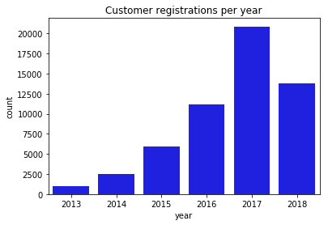

```python
# customer registrations per year
sns.countplot(x="year", data=reg_date, color='b').set_title('Customer registrations per year'); # Countplot info from [R3]
```

Looking at the registration or new customers per year, one sees that the number increases from 2013 until 2017 almost exponential. The number of new members dropped in the plot form 2017 to 2018. But one needs to take care that the dataset stopped in July 2018, so the year 2018 is just almost half a year and if I would interpolate and double the numbers of the so far registered new members in 2018 I could imagine that the 2018 number will increase and be higher than 2017, but this is just an assumption.

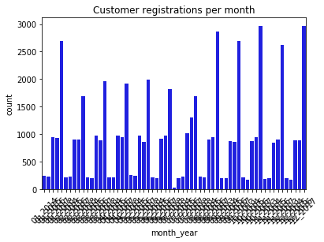

```python
# customer registrations per month and year
sns.countplot(x="month_year", data=reg_date, color='b').set_title('Customer registrations per month'); # Countplot info from [R3]
plt.xticks(rotation=45);
```

not much visible in the plot for the customer registrations per month, so let´s try to plot the registrations per quarter

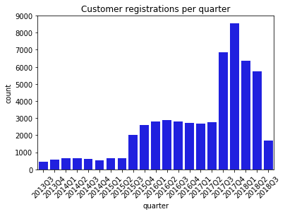

```python
# customer registrations per quarter
sns.countplot(x="quarter", data=reg_date, color='b', order=np.sort(reg_date['quarter'].unique())).set_title('Customer registrations per quarter'); # Countplot info from [R3]
plt.xticks(rotation=45);
```

In this plot it is visible that the numbers of new members are almost constant for the quarters between Q3/2013 and Q1/2015, then there is a increasing jump of the registrations visible which stayed again almost constant until Q2/2017. So now it would be interesting to now if Starbucks increased their advertisement or if other circumstances are responsable for this increase. After Q4 2017, the numbers of new registrations decreased again which could be correlations e.g. with a christmas offer from starbucks, but this information, this could be further investigated.

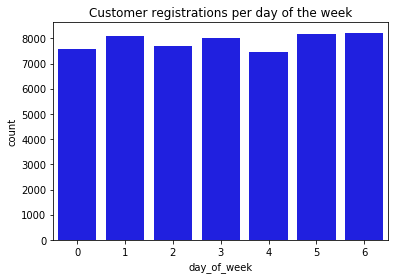

```python
# customer registrations per day of the week
sns.countplot(x="day_of_week", data=reg_date, color='b').set_title('Customer registrations per day of the week'); # Countplot info from [R3]
```

The new registration per day of the week are more or less equal, so it does not look like there is any day prefered or neglected for a new registration.

### Age of the customers

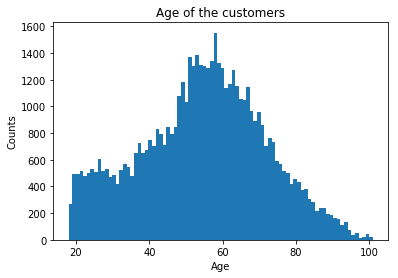

```python
# age of the customers
plt.hist(df_offer.age, bins=len(df_offer.age.unique()));
plt.xlabel('Age');
plt.ylabel('Counts');
plt.title('Age of the customers');
```

```python
df_offer.age.describe()
```

```
count    55222.000000
mean        54.349969
std         17.392733
min         18.000000
25%         42.000000
50%         55.000000
75%         66.000000
max        101.000000
Name: age, dtype: float64
```

The majority of the registered customers have an age between 42 and 66 with a mean of ~ 54years.

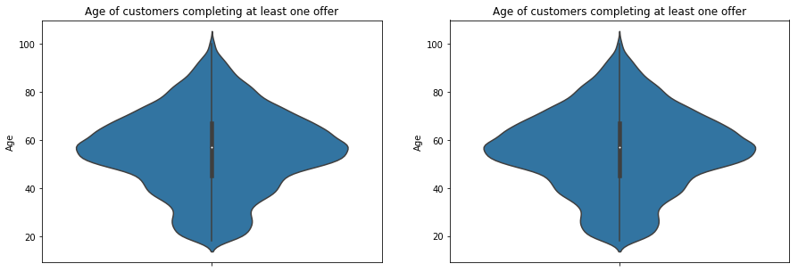

```python
## create plots showing the age distribution of customers which completed at least one or all offers
plt.figure(figsize = [15, 5])

# first plot showing the age distribution of customers which completed at least one offer
plt.subplot(1, 2, 1)
sns.violinplot(y=df_offer[df_offer['offer_completed_counts']>0]["age"])
plt.ylabel('Age');
plt.title('Age of customers completing at least one offer');

# second plot showing the age distribution of customers which completed all offers
plt.subplot(1, 2, 2)
sns.violinplot(y=df_offer[df_offer['all_received_offers_completed']==1]["age"])
plt.ylabel('Age');
plt.title('Age of customers completing at least one offer');
```

```python
df_offer[df_offer['all_received_offers_completed']==1].age.describe()
```

```
count    25922.000000
mean        55.829797
std         16.801793
min         18.000000
25%         45.000000
50%         57.000000
75%         67.000000
max        101.000000
Name: age, dtype: float64
```

The age of the registered customers completing all offers are pretty close to the ages of all registered customers.

### Gender distribution

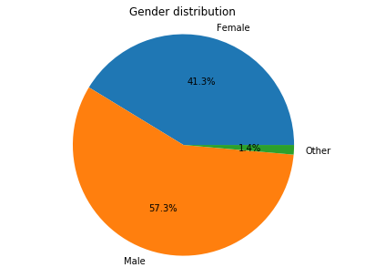

```python
## Gender distribution
plt.figure(figsize = [15, 5])

# gender disctribution as pie plot
plt.subplot(1, 2, 1)
gender_dist = df_offer[['gender_F', 'gender_M', 'gender_O']]
plt.pie(gender_dist.sum().values, labels=['Female', 'Male', 'Other'], autopct='%.1f%%');
plt.title('Gender distribution');
plt.axis('equal');
```

```python
df_offer[['gender_F', 'gender_M', 'gender_O']].sum()
```

```
gender_F    22808
gender_M    31645
gender_O      769
dtype: int64
```

Around ~31500 (~22800) or ~57% (~41%) of the registered customers are male (female), while 769 or 1.4% have selected neither male nor female as gender.

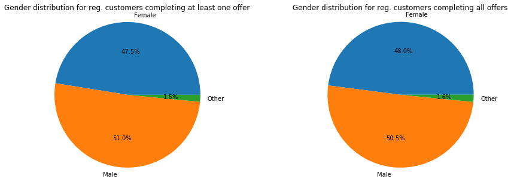

```python
## Gender distribution of registered customers who completed at least one offer
plt.figure(figsize = [15, 5])

# Gender distribution of registered customers who completed at least one offer
plt.subplot(1, 2, 1)
gender_dist = df_offer[df_offer['offer_completed_counts']>0][['gender_F', 'gender_M', 'gender_O']]
plt.pie(gender_dist.sum().values, labels=['Female', 'Male', 'Other'], autopct='%.1f%%');
plt.title('Gender distribution for reg. customers completing at least one offer');
plt.axis('equal');

# Gender distribution of registered customers who completed all offers
plt.subplot(1, 2, 2)
gender_dist = df_offer[df_offer['all_received_offers_completed']==1][['gender_F', 'gender_M', 'gender_O']]
plt.pie(gender_dist.sum().values, labels=['Female', 'Male', 'Other'], autopct='%.1f%%');
plt.title('Gender distribution for reg. customers completing all offers');
plt.axis('equal');
```

```python
# Gender distribution of registered customers who completed at least one offer
df_offer[df_offer['offer_completed_counts']>0][['gender_F', 'gender_M', 'gender_O']].sum()
```

```
gender_F    13259
gender_M    14254
gender_O      429
dtype: int64
```

```python
# Gender distribution of registered customers who completed all offers
df_offer[df_offer['all_received_offers_completed']==1][['gender_F', 'gender_M', 'gender_O']].sum()
```

```
gender_F    12433
gender_M    13079
gender_O      410
dtype: int64
```

Looking at the registered customers who completed at least one offer or all offers, it is obvious that the percentage of the female registered customers completing at least one offer increases in the gender distribution.  
Therefore on this first look it could be that females are more likely to complete an offer than males.

### Offer state depending on the gender

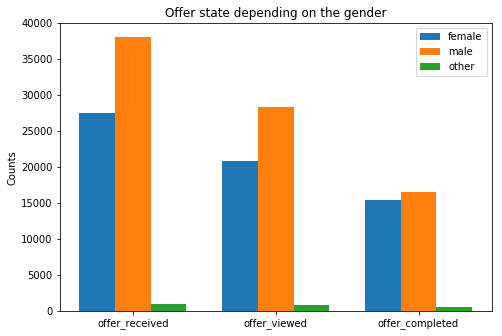

```python
# female sub dataset
df_female = df_offer[df_offer.gender_F == 1]
# male sub dataset
df_male = df_offer[df_offer.gender_M == 1]
# other gender sub dataset
df_other = df_offer[df_offer.gender_O == 1]

# create multiple bar plots [R4]
data = [df_female[['offer_received_counts', 'offer_viewed_counts', 'offer_completed_counts']].sum(),
        df_male[['offer_received_counts', 'offer_viewed_counts', 'offer_completed_counts']].sum(),
        df_other[['offer_received_counts', 'offer_viewed_counts', 'offer_completed_counts']].sum()]
X = np.arange(3)
# plot data
fig = plt.figure()
ax = fig.add_axes([0,0,1,1]);
ax.bar(X + 0.00, data[0], width = 0.25);
ax.bar(X + 0.25, data[1], width = 0.25);
ax.bar(X + 0.50, data[2], width = 0.25);
ax.set_ylabel('Counts')
ax.legend(labels=['female', 'male', 'other']);
ax.set_title('Offer state depending on the gender')
# Set the ticks and ticklabels for all axes [5]
plt.setp(ax, xticks=[0.25, 1.25, 2.25], xticklabels=['offer_received', 'offer_viewed', 'offer_completed']);
```

Even if it is still obvious that males are more often registered than females, one also sees on the above plots that assumption the female bars does not drop so fast compared to the male bars indicating that the percentage fo females will more likely complete an offer compared to the male.

### Income histogram

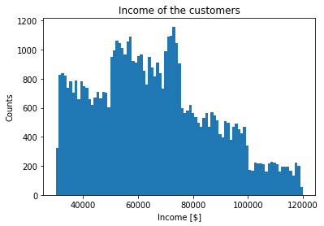

```python
plt.hist(df_offer.income, bins=len(df.income.unique()));
plt.xlabel('Income [$]');
plt.ylabel('Counts');
plt.title('Income of the customers');
```

```python
df_offer.income.describe()
```

```
count     55222.000000
mean      65388.595125
std       21626.373809
min       30000.000000
25%       49000.000000
50%       63000.000000
75%       80000.000000
max      120000.000000
Name: income, dtype: float64
```

The income of the registered customers is between \$30,000 and \\$120,000, while the mean is about \$65,000 and the median at \\$63,000.

### Offer type distribution

```
offer_bogo             22062.0
offer_discount         22119.0
offer_informational    11041.0
dtype: float64
```

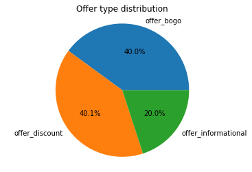

```python
# offer type distribution as pie plot
offer_dist = df_offer[['offer_bogo', 'offer_discount', 'offer_informational']].sum()
plt.pie(offer_dist.values, labels=offer_dist.index, autopct='%.1f%%');
plt.title('Offer type distribution');
plt.axis('equal');
print(offer_dist)
```

The distribution of the types of offers are shows above. The pie plot shows that around 40% of the offers are bogo´s (buy one-get one free) and another 40% are discounts, while the last 20% are informational offers.

### Offer state of each offer type

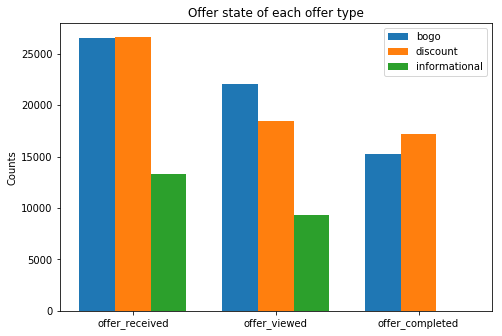

```python
# bogo sub dataset
df_bogo = df_offer[df_offer.offer_bogo == 1]
# offer_discountsub dataset
df_discount = df_offer[df_offer.offer_discount == 1]
# offer_informational sub dataset
df_informational = df_offer[df_offer.offer_informational == 1]

# create multiple bar plots [R4]
data = [df_bogo[['offer_received_counts', 'offer_viewed_counts', 'offer_completed_counts']].sum(),
        df_discount[['offer_received_counts', 'offer_viewed_counts', 'offer_completed_counts']].sum(),
        df_informational[['offer_received_counts', 'offer_viewed_counts', 'offer_completed_counts']].sum()]
X = np.arange(3)
# plot data
fig = plt.figure()
ax = fig.add_axes([0,0,1,1]);
ax.bar(X + 0.00, data[0], width = 0.25);
ax.bar(X + 0.25, data[1], width = 0.25);
ax.bar(X + 0.50, data[2], width = 0.25);
ax.set_ylabel('Counts')
ax.legend(labels=['bogo', 'discount', 'informational']);
ax.set_title('Offer state of each offer type')
# Set the ticks and ticklabels for all axes [5]
plt.setp(ax, xticks=[0.25, 1.25, 2.25], xticklabels=['offer_received', 'offer_viewed', 'offer_completed']);
```

This plot shows that the number of received offers between bogo and discount are almost the same.  
Interesting is that more bogo offer has been viewed than discount offer, the last bars show that the completed offers are more often discounts than bogo´s.

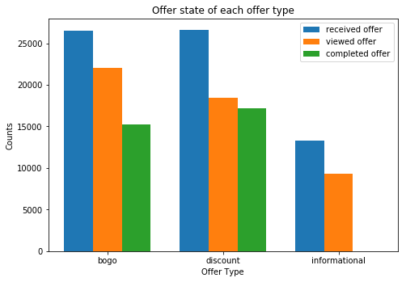

```python
## create other plot showing the percentage of the completed offer
#  and the viewed offer per offer type
# bogo sub dataset
df_bogo = df_offer[df_offer.offer_bogo == 1]
# offer_discountsub dataset
df_discount = df_offer[df_offer.offer_discount == 1]
# offer_informational sub dataset
df_informational = df_offer[df_offer.offer_informational == 1]

data = [[df_bogo['offer_received_counts'].sum(), df_discount['offer_received_counts'].sum(), df_informational['offer_received_counts'].sum()],
        [df_bogo['offer_viewed_counts'].sum(), df_discount['offer_viewed_counts'].sum(), df_informational['offer_viewed_counts'].sum()],
        [df_bogo['offer_completed_counts'].sum(), df_discount['offer_completed_counts'].sum(), df_informational['offer_completed_counts'].sum()]]

X = np.arange(3)
# plot data
fig = plt.figure()
ax = fig.add_axes([0,0,1,1]);
ax.bar(X + 0.00, data[0], width = 0.25);
ax.bar(X + 0.25, data[1], width = 0.25);
ax.bar(X + 0.5, data[2], width = 0.25);
ax.set_ylabel('Counts')
ax.set_xlabel('Offer Type')
ax.legend(labels=['received offer', 'viewed offer', 'completed offer']);
ax.set_title('Offer state of each offer type')
# Set the ticks and ticklabels for all axes [5]
plt.setp(ax, xticks=[0.25, 1.25, 2.25], xticklabels=['bogo', 'discount', 'informational']);
```

This plot makes it a bit more clear that discount offers which have been viewed are most likely to be completed. The decrease steps from the received to the viewed and completed bogo offers are pretty similar leaving the discount offer the most often completed one.

### Offer success (completion) depending on the age

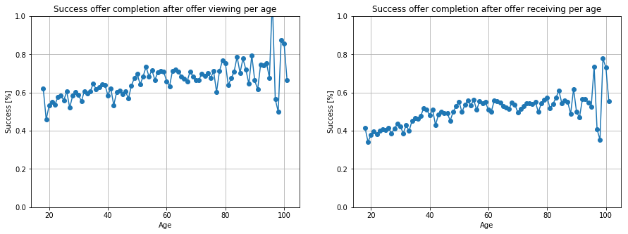

```python
##succesful (at least one offer completed) offers per age
offer_completed_age = df_offer[df_offer['offer_completed_counts']>0].groupby('age').customer_id.count()
offer_viewed_age = df_offer[df_offer['offer_viewed_counts']>0].groupby('age').customer_id.count()
offer_received_age = df_offer[df_offer['offer_received_counts']>0].groupby('age').customer_id.count()
plt.figure(figsize = [15, 5])

# first plot showing the percentage of succesful offers per age
plt.subplot(1, 2, 1)
# plot percentage of succesful offers per age
plt.plot(offer_completed_age / offer_viewed_age, marker='o')
# customize plot
plt.grid(True) # add grid
plt.xlabel('Age');
plt.ylim(0,1)
plt.ylabel('Success [%]');
plt.title('Success offer completion after offer viewing per age');

# second plot showing the percentage of succesful offers per age
plt.subplot(1, 2, 2)
# plot percentage of succesful offers per age
plt.plot(offer_completed_age / offer_received_age, marker='o')
# customize plot
plt.grid(True) # add grid
plt.xlabel('Age');
plt.ylim(0,1)
plt.ylabel('Success [%]');
plt.title('Success offer completion after offer receiving per age');
```

The left plot shows the completion rate of at least one offer if the offer has been viewed depending on the age. Starting from an age of around 35 the completion rate is slowly slowly increasingly oscillating with the age. In other words between around 40 years and around 95 years is the completion rate if the offer has been viewed between 60\% and 80\% which is quite high.  
On the other hand, the right plot shows the completion rate of at least one offer if the offer has been received depending on the age. Here it is not clear if the offer has been viewed or not. The completion rate is also slowly increasing with the age here, similar to the previous plot, but from 20 years up to 90 years, the completion rate if the offer has been reveiced is between 40\% and 60\% which is about 20\% lower.

### Offer success (completion) depending on the income

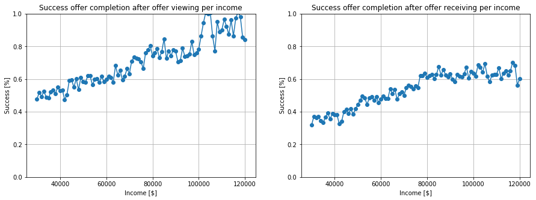

```python
##succesful (at least one offer completed) offers per income
offer_completed_income = df_offer[df_offer['offer_completed_counts']>0].groupby('income').customer_id.count()
offer_viewed_income = df_offer[df_offer['offer_viewed_counts']>0].groupby('income').customer_id.count()
offer_received_income = df_offer[df_offer['offer_received_counts']>0].groupby('income').customer_id.count()
plt.figure(figsize = [15, 5])

# first plot showing the percentage of succesful offers per age
plt.subplot(1, 2, 1)
# plot percentage of succesful offers per age
plt.plot(offer_completed_income / offer_viewed_income, marker='o')
# customize plot
plt.grid(True) # add grid
plt.xlabel('Income [$]');
plt.ylim(0,1)
plt.ylabel('Success [%]');
plt.title('Success offer completion after offer viewing per income');

# second plot showing the percentage of succesful offers per age
plt.subplot(1, 2, 2)
# plot percentage of succesful offers per age
plt.plot(offer_completed_income / offer_received_income, marker='o')
# customize plot
plt.grid(True) # add grid
plt.xlabel('Income [$]');
plt.ylim(0,1)
plt.ylabel('Success [%]');
plt.title('Success offer completion after offer receiving per income');
```

The left plot shows the completion rate of at least one offer if the offer has been viewed depending on the income. The success or completion rate is increasing linearly with the income. Starting from an income of around \$35,000 and a completion rate of 50\% up to a completion rate of about 90\% for registered customers with an income of more than \\$100,000.  
The right plot shows the completion rate of at least one offer if the offer has been received depending on the income. Here it is not clear if the offer has been viewed or not. The completion rate is also increasing linearly with the income, but again starting from a smaller completion rate and in this case also somehow saturating from an income of about \$80,000 and a completion rate between 60\% and 70\%.

### Distribution of the advertisement channels

possible channels were 'email', 'mobile', 'social' or 'web'

```
email     55222.0
mobile    49634.0
social    33088.0
web       44141.0
dtype: float64
```

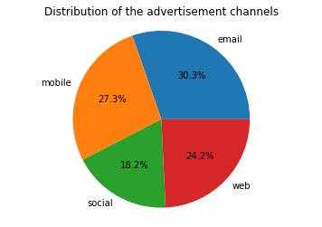

```python
# Distribution of the advertisement channels as pie plot
#possible channels were 'email', 'mobile', 'social' or 'web'
adv_channel_dist = df_offer[['email', 'mobile', 'social', 'web']].sum()
plt.pie(adv_channel_dist.values, labels=adv_channel_dist.index, autopct='%.1f%%');
plt.title('Distribution of the advertisement channels');
plt.axis('equal');
print(adv_channel_dist)
```

The above pie chart shows the distribution of the advertisement channels.  
'email' has been used most with around 55,000 (~30\%) offers, followed by 'mobile' with ~50,000 (27\%) offers. Around a quarter, ~44,000 or ~24\%, of the offers which have been distributed are via 'web' and the fewest offers have been received via 'social' media, around 33,000 or 18\%.

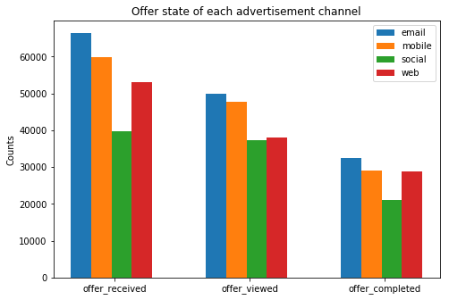

```python
# email sub dataset
df_email = df_offer[df_offer['email'] == 1]
# mobile dataset
df_mobile = df_offer[df_offer['mobile'] == 1]
# social sub dataset
df_social = df_offer[df_offer['social'] == 1]
# web sub dataset
df_web = df_offer[df_offer['web'] == 1]

# create multiple bar plots [R4]
data = [df_email[['offer_received_counts', 'offer_viewed_counts', 'offer_completed_counts']].sum(),
        df_mobile[['offer_received_counts', 'offer_viewed_counts', 'offer_completed_counts']].sum(),
        df_social[['offer_received_counts', 'offer_viewed_counts', 'offer_completed_counts']].sum(),
        df_web[['offer_received_counts', 'offer_viewed_counts', 'offer_completed_counts']].sum()]
X = np.arange(3)
# plot data
fig = plt.figure()
ax = fig.add_axes([0,0,1,1]);
ax.bar(X + 0.00, data[0], width = 0.15);
ax.bar(X + 0.15, data[1], width = 0.15);
ax.bar(X + 0.30, data[2], width = 0.15);
ax.bar(X + 0.45, data[3], width = 0.15);
ax.set_ylabel('Counts')
ax.legend(labels=['email', 'mobile', 'social', 'web']);
ax.set_title('Offer state of each advertisement channel')
# Set the ticks and ticklabels for all axes [5]
plt.setp(ax, xticks=[0.25, 1.25, 2.25], xticklabels=['offer_received', 'offer_viewed', 'offer_completed']);
```

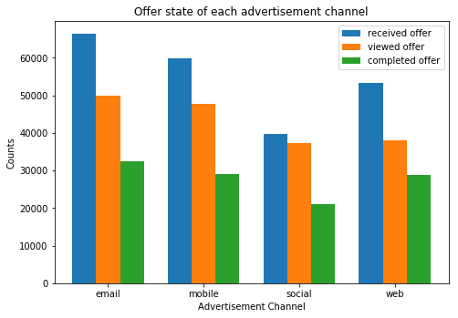

```python
## create other plot showing the percentage of the completed offer and the viewed offer per offer type

# email sub dataset
df_email = df_offer[df_offer['email'] == 1]
# mobile dataset
df_mobile = df_offer[df_offer['mobile'] == 1]
# social sub dataset
df_social = df_offer[df_offer['social'] == 1]
# web sub dataset
df_web = df_offer[df_offer['web'] == 1]

data = [[df_email['offer_received_counts'].sum(),
         df_mobile['offer_received_counts'].sum(),
         df_social['offer_received_counts'].sum(),
         df_web['offer_received_counts'].sum()
        ],
        [df_email['offer_viewed_counts'].sum(),
         df_mobile['offer_viewed_counts'].sum(),
         df_social['offer_viewed_counts'].sum(),
         df_web['offer_viewed_counts'].sum()
        ],
        [df_email['offer_completed_counts'].sum(),
         df_mobile['offer_completed_counts'].sum(),
         df_social['offer_completed_counts'].sum(),
         df_web['offer_completed_counts'].sum()]]

X = np.arange(4)
# plot data
fig = plt.figure()
ax = fig.add_axes([0,0,1,1]);
ax.bar(X + 0.00, data[0], width = 0.25);
ax.bar(X + 0.25, data[1], width = 0.25);
ax.bar(X + 0.50, data[2], width = 0.25);
ax.set_ylabel('Counts')
ax.set_xlabel('Advertisement Channel')
ax.legend(labels=['received offer', 'viewed offer', 'completed offer']);
ax.set_title('Offer state of each advertisement channel')
# Set the ticks and ticklabels for all axes [5]
plt.setp(ax, xticks=[0.25, 1.25, 2.25, 3.25], xticklabels=['email', 'mobile', 'social', 'web']);
```

The most advertisements have been received via 'email', followed by 'mobile' and 'web'. The fewest have been received via 'social' media.  
While the number of views for the first three channel drop by around 10,000 per channel, the number of views is almost equal to the number of received ads via 'social', but this is due to the structure of social media, if you receive an offer, you normally also view it (except from so called private messages).  
Looking at the completed offer, one can see in the above plot that the numbers are nearly equal for 'email', 'mobile' and 'web', while before we saw, that the total number of offers received and viewed are different. The number of completed offer via 'social' media is much smaller than the other three once, but the number of total received offers have been lower as well.  
With the next plot I will go a bit more into detail what is the completion rate for the individual advertisement channels.

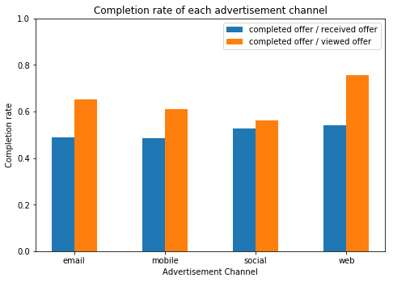

```python
## create other plot showing the completion rate, the ratio between of the completed offer and the viewed offer per offer type

# email sub dataset
df_email = df_offer[df_offer['email'] == 1]
# mobile dataset
df_mobile = df_offer[df_offer['mobile'] == 1]
# social sub dataset
df_social = df_offer[df_offer['social'] == 1]
# web sub dataset
df_web = df_offer[df_offer['web'] == 1]

data = [[df_email['offer_completed_counts'].sum() / df_email['offer_received_counts'].sum(),
         df_mobile['offer_completed_counts'].sum() / df_mobile['offer_received_counts'].sum(),
         df_social['offer_completed_counts'].sum() / df_social['offer_received_counts'].sum(),
         df_web['offer_completed_counts'].sum() / df_web['offer_received_counts'].sum()],
       [df_email['offer_completed_counts'].sum() / df_email['offer_viewed_counts'].sum(),
         df_mobile['offer_completed_counts'].sum() / df_mobile['offer_viewed_counts'].sum(),
         df_social['offer_completed_counts'].sum() / df_social['offer_viewed_counts'].sum(),
         df_web['offer_completed_counts'].sum() / df_web['offer_viewed_counts'].sum()]
       ]

X = np.arange(4)
# plot data
fig = plt.figure()
ax = fig.add_axes([0,0,1,1]);
ax.bar(X + 0.00, data[0], width = 0.25);
ax.bar(X + 0.25, data[1], width = 0.25);
ax.set_ylabel('Completion rate')
ax.set_xlabel('Advertisement Channel')
ax.set_ylim(0,1)
ax.legend(labels=['completed offer / received offer', 'completed offer / viewed offer']);
ax.set_title('Completion rate of each advertisement channel')
# Set the ticks and ticklabels for all axes [4]
plt.setp(ax, xticks=[0.125, 1.125, 2.125, 3.125], xticklabels=['email', 'mobile', 'social', 'web']);
```

The last plot shows that the received completion rate of the completed offer / received offer (blue in the above plot) is more or less equal through all advertisement channels, but if the offer has been viewed (orange in the above plot), the highest completion rate is visible for the 'web' channel with an increase of about 25\%, followed by 'email' with an increase of about 20\%.

### Histogram of time since offer start

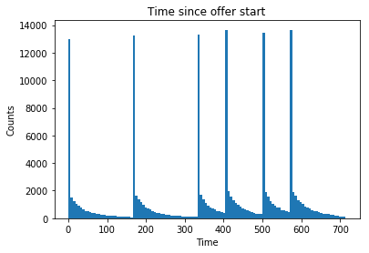

```python
plt.hist(df_offer_all.time_since_offer_start, bins=len(df.time_since_offer_start.unique()));
plt.xlabel('Time');
plt.ylabel('Counts');
plt.title('Time since offer start');
```

The plot above shows the times since an offer starts.

## 4. Machine Learning approche for recommendations

At the end, I uses a machine learning approche for the recommendation of the most relevant features of the customers which have been completed all offers. This relevant features can be used to improve the advertisement and increase the amount of completed offers.

## 4.1 Prepare data for a machine learning approche

First of all, a feature data frame needs to be created.

```python
# the used features are the following
ml_features = df_offer[['age', 'income',
                  'gender_F', 'gender_M', 'gender_O',
                  'offer_bogo', 'offer_discount', 'offer_informational',
                  'difficulty', 'duration',
                  'email', 'mobile', 'social', 'web']]
```

```python
ml_features.isnull().sum()
```

```
age                    0
income                 0
gender_F               0
gender_M               0
gender_O               0
offer_bogo             0
offer_discount         0
offer_informational    0
difficulty             0
duration               0
email                  0
mobile                 0
social                 0
web                    0
dtype: int64
```

```python
# the reference if an advertisement was successful is the column 'offer_completed'
offer_completed = df_offer['all_received_offers_completed']
```

```python
# split the data into training and testing data
# use 20% as testing data and the random_state=42
X_train, X_test, y_train, y_test = train_test_split(ml_features, offer_completed, test_size=0.2, random_state=42)
```

## 4.2 Test different machine learning models (Gaussian Naive Bayes, Adaboost and the RandomForestClassifier)

As a starting point I tested three different machine learning models, a naive bayes model (Gaussian Naive Bayes) and two ensemble models (Adaboost and RandomForestClassifier) with the standard parameters.

```python
# define a function to train a ml model and predict results [R6]
def train_predict(ml_model, sample_size, X_train, y_train, X_test, y_test):
    '''
    inputs:
       - ml_model: the ml model algorithm to be trained and predicted on
       - sample_size: the size of samples (number) to be drawn from training set
       - X_train: features training set
       - y_train: income training set
       - X_test: features testing set
       - y_test: income testing set
    '''

    results = {}

    # Fit the learner to the training data using slicing with 'sample_size' using .fit(training_features[:], training_labels[:])
    start = time() # Get start time
    ml_model.fit(X_train[:sample_size], y_train[:sample_size])
    end = time() # Get end time

    # Calculate the training time
    results['train_time'] = end - start;

    # Get the predictions on the test set(X_test),
    # then get predictions on the first 300 training samples(X_train) using .predict()
    start = time() # Get start time
    predictions_test = ml_model.predict(X_test)
    predictions_train = ml_model.predict(X_train[:300])
    end = time() # Get end time

    # Calculate the total prediction time
    results['pred_time'] = end - start;

    # Compute accuracy on the first 300 training samples which is y_train[:300]
    results['acc_train'] = accuracy_score(y_train[:300], predictions_train)

    # Compute accuracy on test set using accuracy_score()
    results['acc_test'] = accuracy_score(y_test, predictions_test)

    # Compute F-score on the the first 300 training samples using fbeta_score()
    results['f_train'] = fbeta_score(y_train[:300], predictions_train, beta=0.5)

    # Compute F-score on the test set which is y_test
    results['f_test'] = fbeta_score(y_test, predictions_test, beta=0.5)

    # Success
    print("{} trained on {} samples.".format(ml_model.__class__.__name__, sample_size))

    # Return the results
    return results
```

```python
# reuse evaluate(results) function from a previous course, Udacity Nanodegree: Introduction to Machine Learning [R6]
def evaluate(results):
    """
    Visualization code to display results of various learners.

    inputs:
      - learners: a list of supervised learners
      - stats: a list of dictionaries of the statistic results from 'train_predict()'
    """

    # Create figure
    fig, ax = plt.subplots(2, 3, figsize = (11,7))

    # Constants
    bar_width = 0.3
    colors = ['#A00000','#00A0A0','#00A000']

    # Super loop to plot four panels of data
    for k, learner in enumerate(results.keys()):
        for j, metric in enumerate(['train_time', 'acc_train', 'f_train', 'pred_time', 'acc_test', 'f_test']):
            for i in np.arange(3):

                # Creative plot code
                ax[j//3, j%3].bar(i+k*bar_width, results[learner][i][metric], width = bar_width, color = colors[k])
                ax[j//3, j%3].set_xticks([0.45, 1.45, 2.45])
                ax[j//3, j%3].set_xticklabels(["1%", "10%", "100%"])
                ax[j//3, j%3].set_xlabel("Training Set Size")
                ax[j//3, j%3].set_xlim((-0.1, 3.0))

    # Add unique y-labels
    ax[0, 0].set_ylabel("Time (in seconds)")
    ax[0, 1].set_ylabel("Accuracy Score")
    ax[0, 2].set_ylabel("F-score")
    ax[1, 0].set_ylabel("Time (in seconds)")
    ax[1, 1].set_ylabel("Accuracy Score")
    ax[1, 2].set_ylabel("F-score")

    # Add titles
    ax[0, 0].set_title("Model Training")
    ax[0, 1].set_title("Accuracy Score on Training Subset")
    ax[0, 2].set_title("F-score on Training Subset")
    ax[1, 0].set_title("Model Predicting")
    ax[1, 1].set_title("Accuracy Score on Testing Set")
    ax[1, 2].set_title("F-score on Testing Set")

    # Set y-limits for score panels
    ax[0, 1].set_ylim((0, 1))
    ax[0, 2].set_ylim((0, 1))
    ax[1, 1].set_ylim((0, 1))
    ax[1, 2].set_ylim((0, 1))

    # Create patches for the legend
    patches = []
    for i, learner in enumerate(results.keys()):
        patches.append(mpatches.Patch(color = colors[i], label = learner))
    plt.legend(handles = patches, bbox_to_anchor = (-.80, 2.53), \
               loc = 'upper center', borderaxespad = 0., ncol = 3, fontsize = 'x-large')

    # Aesthetics
    plt.suptitle("Performance Metrics for Three Supervised Learning Models", fontsize = 16, y = 1.10)
    plt.tight_layout()
    plt.show()
```

```
GaussianNB trained on 441 samples.
GaussianNB trained on 4417 samples.
GaussianNB trained on 44177 samples.
AdaBoostClassifier trained on 441 samples.
AdaBoostClassifier trained on 4417 samples.
AdaBoostClassifier trained on 44177 samples.
RandomForestClassifier trained on 441 samples.
RandomForestClassifier trained on 4417 samples.
RandomForestClassifier trained on 44177 samples.
```

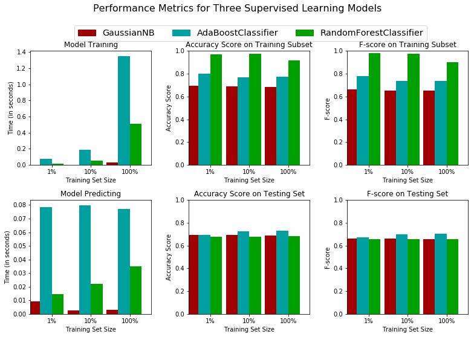

```python
# Initialize the three models
clf_A = GaussianNB()
clf_B = AdaBoostClassifier(random_state=42)
clf_C = RandomForestClassifier(random_state=42)

# Calculate the number of samples for 1%, 10%, and 100% of the training data
samples_100 = len(y_train)
samples_10 = int(len(y_train)/10)
samples_1 = int(len(y_train)/100)

# Collect results on the ml model learners
results = {}
for clf in [clf_A, clf_B, clf_C]:
    clf_name = clf.__class__.__name__
    results[clf_name] = {}
    for i, samples in enumerate([samples_1, samples_10, samples_100]):
        results[clf_name][i] = \
        train_predict(clf, samples, X_train, y_train, X_test, y_test)

# Run metrics visualization for the three supervised learning models chosen
evaluate(results)
```

The top plots show the performance of the three machine learning models on the training set, while the bottom plots show the accuracy and F-score on the testing set. Due to the results, I continued with the AdaBoost classifier, because he has the best results on the test dataset.

## 4.3 Tuning of the machine learning model

I tested different parameter sets to find the best predicting combination of parameters for the AdaBoost classifier.

```python
## code is also reused from the old Udacity Nanodegree course [R6]
# Initialize the classifier
clf = AdaBoostClassifier(random_state=42)

# Create the parameters list you wish to tune, using a dictionary if needed.
parameters = {'n_estimators': [50, 100, 150, 200, 250, 300], 'learning_rate': [0.01, 0.1, 0.5, 1.0, 2.0]}

# Make an fbeta_score scoring object using make_scorer()
scorer = make_scorer(fbeta_score, beta=0.5)

# Perform grid search on the classifier using 'scorer' as the scoring method using GridSearchCV()
grid_obj = GridSearchCV(clf, parameters, scoring=scorer)

# Fit the grid search object to the training data and find the optimal parameters using fit()
grid_fit = grid_obj.fit(X_train, y_train)

# Get the estimator
best_clf = grid_fit.best_estimator_

# Make predictions using the unoptimized and model
predictions = (clf.fit(X_train, y_train)).predict(X_test)
best_predictions = best_clf.predict(X_test)

# Report the before-and-afterscores
print("Unoptimized model\n------")
print("Accuracy score on testing data: {:.4f}".format(accuracy_score(y_test, predictions)))
print("F-score on testing data: {:.4f}".format(fbeta_score(y_test, predictions, beta = 0.5)))
print("\nOptimized Model\n------")
print("Final accuracy score on the testing data: {:.4f}".format(accuracy_score(y_test, best_predictions)))
print("Final F-score on the testing data: {:.4f}".format(fbeta_score(y_test, best_predictions, beta = 0.5)))
```

```
Unoptimized model
------
Accuracy score on testing data: 0.7314
F-score on testing data: 0.7008

Optimized Model
------
Final accuracy score on the testing data: 0.7328
Final F-score on the testing data: 0.7030
```

The final accuracy and the final F-score increased slightly after searching for the optimal parameter using GridSearchCV.

## 4.4 Get most predictive features

```python
## define function to plot the five most predictive features
# reuse feature_plot(importances, X_train, y_train) function from a previous course, Udacity Nanodegree: Introduction to Machine Learning [R6]
def feature_plot(importances, X_train, y_train):

    # Display the five most important features
    indices = np.argsort(importances)[::-1]
    columns = X_train.columns.values[indices[:5]]
    values = importances[indices][:5]

    # Creat the plot
    fig = plt.figure(figsize = (9,5))
    plt.title("Normalized Weights for First Five Most Predictive Features", fontsize = 16)
    plt.bar(np.arange(5), values, width = 0.6, align="center", color = '#00A000', \
            label = "Feature Weight")
    plt.bar(np.arange(5) - 0.3, np.cumsum(values), width = 0.2, align = "center", color = '#00A0A0', \
            label = "Cumulative Feature Weight")
    plt.xticks(np.arange(5), columns)
    plt.xlim((-0.5, 4.5))
    plt.ylabel("Weight", fontsize = 12)
    plt.xlabel("Feature", fontsize = 12)

    plt.legend(loc = 'upper center')
    plt.tight_layout()
    plt.show()
```

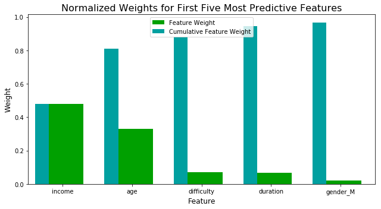

```python
## Extracting Feature Importance
# Extract the feature importances of the best classifier using .feature_importances_
importances = best_clf.feature_importances_
# feature_plot
feature_plot(importances, X_train, y_train)
```

The five most predictive features are shown in the above plots.  
As assumed from the data exploration the most predictive features are the *income* and the *age* with a hugh distance to the next important features, *duration* and *difficulty*. The fifth most important feature is the gender 'male'. Deducing from this, I would recommend to focus on the age, income and gender of the customer, taking into account the diificulty and duration.

## 5. Results

- The data investigation should that the completion rate increased with customer age. In addition, if one gets the customer to view the offer, the completion rate is between 60% and 80% for users between around 40 years and 95 years.
- The income has a similar behaviour as the age. The success or completion rate is increasing linearly with the income. Starting from an income of around \$35,000 and a completion rate of 50\% up to a completion rate of about 90\% for registered customers with an income of more than \\$100,000.
- Looking at the registered customers who completed all offers, it is obvious that the percentage of the female registered customers completing all offers increases compared to the total gender distribution. Therefore on this first look it could be that females are more likely to complete an offer than males.
- The received completion rate of the completed offer / received offer is more or less equal through all advertisement channels, but if the offer has been viewed, the highest completion rate is visible for the 'web' channel with an increase of about 25\%, followed by 'email' with an increase of about 20\%.
- Discount offers which have been viewed are most likely to be completed. The decrease steps from the received to the viewed and completed bogo offers are pretty similar leaving the discount offer the most often completed one.
- The machine learning approche identified the five most predictive feaures which are *income* and the *age* with a hugh distance to the next important features, *duration* and *difficulty*. The fifth most important feature is the *gender male*. Deducing from this, I would recommend to focus on the age, income and gender of the customer, taking into account the diificulty and duration.

  Looking at these results, I would recommend Starbucks to focus on the age, income and gender of the customer and taking into account the difficulty and duration as well as the advertising channel of the offers.  
  So overall the best rate for completing all offers are given for an elder female customer with a high income of at least \$80,000. The offer should be a discount and distributed via *web*, *email* or *mobile* (in this order).

### Improvements

There are plenty of possibilities to improve the analysis performed in this project. But as always one needs to start somewhere and this was my starting point which gives already a pretty nice overview of the Starbucks customers and their behaviour. Some possible future improvements are listed below:

- So far I have not looked so much into the details of recorded transcation data, because I focused on the offers iself. But the transaction data and the times could give additional information about the customers and their behaviour.
- During the data exploration, some features like difficulty, duration and the rewards have also not been investigatd so much into detail, this could be improved.
- Besides this, the machine learning approche is just a first shot with an accuary of around 74% which could be improved using better pre-trained models or even increase the parameter space for the selected AdaBoost classifier by using GridSeachCV.

### Reflection

The challange in data science and especially in this project is to ask the right questions.  
What kind of information are hidden in the data sets and what insights can be made etc.

I really enjoyed investigating the data and find insights in the data which are not directly visible (Multivariate Exploration) like the offer completion rate after receiving or viewing an offer depending on the age or income. In addition, developing a machine learning is always fun. Preparing the data, use some pre-trained models and seeing the model improving by adjusting the parameter and receiving better predictions is always fascinating.

# References

[R1]: Panda docu - json normalize: https://pandas.pydata.org/pandas-docs/stable/reference/api/pandas.json_normalize.html  
[R2]: Stakeoverlflow Reorder columns: https://stackoverflow.com/questions/13148429/how-to-change-the-order-of-dataframe-columns  
[R3] Seaborn docu - Countplot: https://seaborn.pydata.org/generated/seaborn.countplot.html  
[R4] Create multiple barplot: https://www.tutorialspoint.com/matplotlib/matplotlib_bar_plot.htm  
[R5] Set the ticks and ticklabels for all axes: https://stackoverflow.com/questions/19626530/python-xticks-in-subplots  
[R6] function "train_predict" and implementation of the three ml models have been created by myself in an earlier Udacity Nanodegree course: https://github.com/jsksoft/IntroToMachineLearning_ND_2020/blob/main/2_finding_donors/finding_donors.ipynb  
[R7] Merging data frames: https://pandas.pydata.org/pandas-docs/stable/user_guide/merging.html  
[R8] Comparing two columns in pandas: https://stackoverflow.com/questions/27474921/compare-two-columns-using-pandas